# Il benessere degli europei: un’analisi sul rapporto tra la famiglia e la felicità.

Gruppo 5: Ballabio, Carobene, Barbazza, Villani

2023-06-19

## Titolo

> L’importanza della famiglia nel benessere quotidiano, inteso in termini di felicità e soddisfazione percepita.

## Obiettivi e Metodologia

### 1. Domanda di ricerca ed obiettivi

> É importante avere una famiglia per poter raggiungere la felicità?

La ricerca si propone di esplorare l’**importanza** della **famiglia** nel raggiungimento della **felicità** e in generale di una vita piena e soddisfacente.

Saranno presi in considerazione **diversi fattori** correlati, come la qualità del tempo speso in famiglia, l’importanza data agli amici, il tempo libero e altri aspetti sociali.

### 2. Fonte dati

I dati per questa ricerca verranno ricavati dall’*European Social Survey*.

### 3. Paesi analizzati

La ricerca si concentrerà su un’ampia gamma di paesi europei, ad **eccezione** dei seguenti: Kosovo, Lettonia, Lussemburgo, Montenegro, Macedonia del Nord, Romania, Serbia, Turchia, Israele. Di questi ultimi i dati sono troppo scarsi.

### 4. Range temporale

L’unico anno che presenta abbastanza dati per un’analisi è il 2018.

### 5. Le ipotesi

**H1** La presenza di una famiglia è considerata un elemento importante per raggiungere la felicità.

1. L’importanza della famiglia è correlata alla felicità.
2. L’importanza della famiglia è correlata alla soddisfazione nella vita percepita.

## Il Dataset

### Creazione

> Selezione variabili e Filtro sulle osservazioni

```r
# per la lettura di file.csv di grandi dimensioni
library(data.table)

# percorso dataset
file_csv <- "/Users/NicolòBallabio/OneDrive - ITS Angelo Rizzoli/Documenti/Corsi Attivi/R/Lezione 3 -- 10.5/Dataset progetto/ESS-Data-Wizard-subset-2023-05-07.csv"

# variabile da usare poi come filtro;
# contiene solo le variabili di interesse
old_names <- c('cntry', 'proddate', 'gndr', 'impfml', 'prrfmly', 'fmlenj',
               'fmlstrs', 'stflife','impfrds', 'implsrt', 'imppol',
               'imprlg', 'impvo', 'impwrk', 'happy')

# lettura dataset con fread() di data.table
dati <- fread(file_csv, select = old_names)

# nuovi nomi per le variabili
new_names <- c('Country', 'Production_Date', 'Gender', 'Family_Importance', 'Family_Main_Priority_Life',
               'Family_Time_Enjoyable', 'Family_Time_Stressful', 'Life_Satisfaction',
               'Friends_Importance', 'Leisure_Time_Importance',
               'Politics_Importance', 'Religion_Importance','Volunteering_Importance', 'Work_Importance',                'Happiness')
# cambio nome
setnames(dati, old = old_names, new = new_names)

# stampa su file
output_csv <- getwd()
# dati grezzi (variabili numeriche) per analisi con la media
dati_raw <- dati
```

### Presentazione

> Quante e quali sono le variabili incluse nel dataset? Cosa rappresentano? Quali valori possono assumere le variabili? Che tipo di variabili sono?

Le variabili selezionate per l’analisi sono quelle relative alla famiglia:

```r
names(dati)
```

```
##  [1] "Country"                   "Production_Date"
##  [3] "Gender"                    "Family_Importance"
##  [5] "Family_Main_Priority_Life" "Family_Time_Enjoyable"
##  [7] "Family_Time_Stressful"     "Life_Satisfaction"
##  [9] "Friends_Importance"        "Leisure_Time_Importance"
## [11] "Politics_Importance"       "Religion_Importance"
## [13] "Volunteering_Importance"   "Work_Importance"
## [15] "Happiness"
```

Sono variabili categoriche:

```r
str(dati)
```

```
## Classes 'data.table' and 'data.frame':   483089 obs. of  15 variables:
##  $ Country                  : chr  "AT" "AT" "AT" "AT" ...
##  $ Production_Date          : chr  "01.12.2018" "01.12.2018" "01.12.2018" "01.12.2018" ...
##  $ Gender                   : int  1 1 2 1 2 2 2 2 1 2 ...
##  $ Family_Importance        : int  8 8 10 10 10 10 10 10 10 10 ...
##  $ Family_Main_Priority_Life: int  NA NA NA NA NA NA NA NA NA NA ...
##  $ Family_Time_Enjoyable    : int  NA NA NA NA NA NA NA NA NA NA ...
##  $ Family_Time_Stressful    : int  NA NA NA NA NA NA NA NA NA NA ...
##  $ Life_Satisfaction        : int  8 0 8 9 9 3 10 7 4 7 ...
##  $ Friends_Importance       : int  8 8 8 9 10 10 9 10 10 5 ...
##  $ Leisure_Time_Importance  : int  7 10 10 8 8 10 8 10 7 8 ...
##  $ Politics_Importance      : int  4 2 3 7 2 10 8 9 0 5 ...
##  $ Religion_Importance      : int  2 0 7 3 9 0 8 0 5 5 ...
##  $ Volunteering_Importance  : int  2 10 0 3 8 4 7 5 5 8 ...
##  $ Work_Importance          : int  4 3 8 7 8 6 8 7 7 10 ...
##  $ Happiness                : int  8 4 7 9 9 5 9 7 4 7 ...
##  - attr(*, ".internal.selfref")=<externalptr>
```

## Elaborazione dei Dati

### 1. Verifica di consistenza dei dati e correzione delle inconsistenze

Sono presenti dei valori anomali?

Formattazione valori mancanti

```r
# Formattazione valori mancanti
# install.packages("sjmisc")
library(sjmisc)

dati <- set_na(dati, na = c("", "55", "77", "88", "99"))
```

Quanti Nan per variabile

```r
# Numero di valori mancanti per variabile
missing_values <- colSums(is.na(dati))
print(missing_values)
```

```
##                   Country           Production_Date                    Gender
##                         0                         0                         0
##         Family_Importance Family_Main_Priority_Life     Family_Time_Enjoyable
##                    440847                    435552                    441620
##     Family_Time_Stressful         Life_Satisfaction        Friends_Importance
##                    442085                      2859                    440917
##   Leisure_Time_Importance       Politics_Importance       Religion_Importance
##                    441169                    441044                    441027
##   Volunteering_Importance           Work_Importance                 Happiness
##                    441432                    441668                      3168
```

```r
# oppure
# apply(dati, 2, function(x) sum(is.na(x)))
```

Percentuale Nan per Variabile

```r
# Percentuale di missing values per variabile
missing_percent <- colSums(is.na(dati)) / nrow(dati) * 100

# Nomi delle variabili
variable_names <- colnames(dati)

# Combina i nomi delle variabili con le percentuali formattate
formatted_output <- paste(variable_names, sprintf("%.2f%%", missing_percent), sep = ": ")

print(formatted_output)
```

```
##  [1] "Country: 0.00%"                    "Production_Date: 0.00%"
##  [3] "Gender: 0.00%"                     "Family_Importance: 91.26%"
##  [5] "Family_Main_Priority_Life: 90.16%" "Family_Time_Enjoyable: 91.42%"
##  [7] "Family_Time_Stressful: 91.51%"     "Life_Satisfaction: 0.59%"
##  [9] "Friends_Importance: 91.27%"        "Leisure_Time_Importance: 91.32%"
## [11] "Politics_Importance: 91.30%"       "Religion_Importance: 91.29%"
## [13] "Volunteering_Importance: 91.38%"   "Work_Importance: 91.43%"
## [15] "Happiness: 0.66%"
```

Con ggplot2

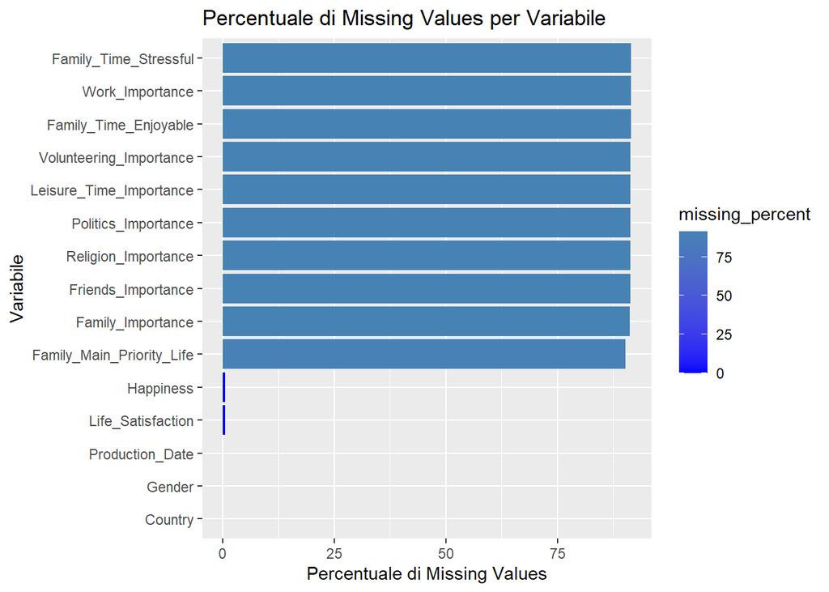

```r
# install.packages("ggplot2")
library(ggplot2)
# Creazione del dataframe con i nomi delle variabili e le percentuali
data <- data.frame(variable = colnames(dati), missing_percent = missing_percent)

# Creazione del grafico a barre
ggplot(data, aes(x = missing_percent,
                 y = reorder(variable, missing_percent),
                 fill = missing_percent)) +
  geom_bar(stat = "identity") +
  scale_fill_gradient(low = "blue", high = "steelblue") +
  labs(x = "Percentuale di Missing Values", y = "Variabile") +
  ggtitle("Percentuale di Missing Values per Variabile")
```

Percentuale di Missing Values nel Dataset

```r
# Percentuale di missing values per variabile
missing_percent <- sprintf("%.2f%%",
                           total_missing_percent <- sum(colSums(is.na(dati))) / (nrow(dati) * ncol(dati)) * 100)
# Formattazione dell'output
# formatted_percent <- sprintf("%.2f%%", missing_percent)
print(missing_percent)
```

```
## [1] "60.91%"
```

Sono presenti dei valori anomali? Come gestirli per evitare che pregiudichino i risultati delle analisi?

Esempio: cerchiamo i valori univoci della variabile Happiness

```r
# valori unici della variabile categorica
unique_values <- unique(dati$Happiness)
print(unique_values)
```

```
##  [1]  8  4  7  9  5  3 10  6 NA  1  2  0
```

Controllo Valori Anomali in tutte le variabili, iterando sulle colonne

```r
library(tidyverse)
# vettore di controllo
control_vector <- c( "0", "1", "2", "3", "4", "5", "6", "7", "8", "9", "10",
                     "Extremely happy",
                     "Extremely unhappy",
                     "Extremely Important",
                     "Extremely Uninmportant", NA)



dati_wo_country <- select(dati, -Country, -Production_Date)
column_names <- names(dati_wo_country)
#print(column_names)

# Itera su ogni colonna
for (column_name in column_names) {
  # valori unici della colonna corrente
  unique_values <- unique(dati[[column_name]])

  # Controlla se c'è almeno un valore unico non presente nel vettore di controllo
  anomaly_detected <- any(!unique_values %in% control_vector)

  # Stampa il nome della colonna e il risultato del controllo
  #print(paste("Colonna:", column_name, "- Anomalia rilevata:", anomaly_detected))


  anomalies <- unique_values[!unique_values %in% control_vector]


  if (length(anomalies) > 0) {
    print(paste("Colonna:", column_name, "- Anomalia rilevata: TRUE"))
    print("Valori anomali:")
    print(anomalies)
  } else {

    # print(paste("Colonna:", column_name, "- Anomalia rilevata: FALSE"))
  }

}
```

### 2. Trasformazione dei dati

> Rinominare le variabili attribuendo nomi di facile intuizione, ricodifica delle variabili

Ricodifica variabile *Country*

```r
library(dplyr)

dati <- mutate(
  dati,
  Country = recode(Country,

  "AL" = "Albania",
  "AT" = "Austria",
  "BE" = "Belgium",
  "BG" = "Bulgaria",
  "CH" = "Switzerland",
  "CY" = "Cyprus",
  "CZ" = "Czechia",
  "DE" = "Germany",
  "DK" = "Denmark",
  "EE" = "Estonia",
  "ES" = "Spain",
  "FI" = "Finland",
  "FR" = "France",
  "GB" = "United Kingdom",
  "GE" = "Georgia",
  "GR" = "Greece",
  "HR" = "Croatia",
  "HU" = "Hungary",
  "IE" = "Ireland",
  "IS" = "Iceland",
  "IL" = "Israel",
  "IT" = "Italy",
  "LT" = "Lithuania",
  "LU" = "Luxembourg",
  "LV" = "Latvia",
  "ME" = "Montenegro",
  "MK" = "North Macedonia",
  "NL" = "Netherlands",
  "NO" = "Norway",
  "PL" = "Poland",
  "PT" = "Portugal",
  "RO" = "Romania",
  "RS" = "Serbia",
  "RU" = "Russian Federation",
  "SE" = "Sweden",
  "SI" = "Slovenia",
  "SK" = "Slovakia",
  "TR" = "Turkey",
  "UA" = "Ukraine",
  "XK" = "Kosovo",
  .default= NA_character_)
  )
```

Ricodifica variabile *Family Importance*

```r
# library(dplyr)

dati$Family_Importance <- ifelse(dati$Family_Importance %in% c("0", "1", "2"), "1. Very Unimportant",
                          ifelse(dati$Family_Importance %in% c("3", "4"), "2. Unimportant",
                          ifelse(dati$Family_Importance %in% c("5", "6"), "3. Neutral",
                          ifelse(dati$Family_Importance %in% c("7", "8"), "4. Important",
                          ifelse(dati$Family_Importance %in% c("9", "10"), "5. Very Important",
                          NA_character_ )))))
# table(dati$Family_Importance)
```

Ricodifica variabile *Gender*

```r
library(dplyr)

dati <- mutate(
  dati,
  Gender = recode(Gender,
                  "1" = "Male",    #valore attuale = valore nuovo
                  "2" = "Female",
                  .default= NA_character_) #tutti i valori non classificati, considerati NA
  )
```

Ricodifica variabile *Family Main Priority Life*

```r
dati <- mutate(
  dati,
  Family_Main_Priority_Life = recode(Family_Main_Priority_Life,
                "1" = "Agree strongly",
                "2" = "Agree",
                "3" = "Neutral",
                "4" = "Disagree",
                "5" = "Disagree strongly",
                  .default= NA_character_) #tutti i valori non classificati, considerati NA
  )
```

Ricodifica variabile *Family Time Enjoyable*

```r
dati$Family_Time_Enjoyable <- ifelse(dati$Family_Time_Enjoyable %in% c("0"), "1. Never",
                          ifelse(dati$Family_Time_Enjoyable %in% c("1", "2"), "2. Rarely",
                          ifelse(dati$Family_Time_Enjoyable %in% c("3"), "3. Neutral",
                          ifelse(dati$Family_Time_Enjoyable %in% c("4", "5"), "4. Often",
                          ifelse(dati$Family_Time_Enjoyable %in% c("6"), "5. All of the time",
                          NA_character_ )))))
```

Ricodifica variabile *Family Time Stressful*

```r
dati$Family_Time_Stressful <- ifelse(dati$Family_Time_Stressful %in% c("0"), "1. Never",
                          ifelse(dati$Family_Time_Stressful %in% c("1", "2"), "2. Rarely",
                          ifelse(dati$Family_Time_Stressful %in% c("3"), "3. Neutral",
                          ifelse(dati$Family_Time_Stressful %in% c("4", "5"), "4. Often",
                          ifelse(dati$Family_Time_Stressful %in% c("6"), "5. All of the time",
                          NA_character_ )))))
```

Ricodifica variabile *Life Satisfaction*

```r
dati$Life_Satisfaction <- ifelse(dati$Life_Satisfaction %in% c("0", "1", "2"), "1. Extremely dissatisfied",
                  ifelse(dati$Life_Satisfaction %in% c("3", "4"), "2. Not Satisfied",
                  ifelse(dati$Life_Satisfaction %in% c("5", "6"), "3. Neutral",
                  ifelse(dati$Life_Satisfaction %in% c("7", "8"), "4. Satisfied",
                  ifelse(dati$Life_Satisfaction %in% c("9", "10"), "5. Extremely satisfied",
                   NA_character_ )))))
```

Ricodifica variabile *Friends Importance*

```r
dati$Friends_Importance <- ifelse(dati$Friends_Importance %in% c("0", "1", "2"), "1. Very Unimportant",
                          ifelse(dati$Friends_Importance %in% c("3", "4"), "2. Unimportant",
                          ifelse(dati$Friends_Importance %in% c("5", "6"), "3. Neutral",
                          ifelse(dati$Friends_Importance %in% c("7", "8"), "4. Important",
                          ifelse(dati$Friends_Importance %in% c("9", "10"), "5. Very Important",
                          NA_character_ )))))
```

Ricodifica variabile *Leisure Time Importance*

```r
dati$Leisure_Time_Importance <- ifelse(dati$Leisure_Time_Importance %in% c("0", "1", "2"), "1. Very Unimportant",
                          ifelse(dati$Leisure_Time_Importance %in% c("3", "4"), "2. Unimportant",
                          ifelse(dati$Leisure_Time_Importance %in% c("5", "6"), "3. Neutral",
                          ifelse(dati$Leisure_Time_Importance %in% c("7", "8"), "4. Important",
                          ifelse(dati$Leisure_Time_Importance %in% c("9", "10"), "5. Very Important",
                          NA_character_ )))))
```

Ricodifica variabile *Politics Importance*

```r
dati$Politics_Importance <- ifelse(dati$Politics_Importance %in% c("0", "1", "2"), "1. Very Unimportant",
                          ifelse(dati$Politics_Importance %in% c("3", "4"), "2. Unimportant",
                          ifelse(dati$Politics_Importance %in% c("5", "6"), "3. Neutral",
                          ifelse(dati$Politics_Importance %in% c("7", "8"), "4. Important",
                          ifelse(dati$Politics_Importance %in% c("9", "10"), "5. Very Important",
                          NA_character_ )))))
```

Ricodifica variabile *Religion Importance*

```r
dati$Religion_Importance <- ifelse(dati$Religion_Importance %in% c("0", "1", "2"), "1. Very Unimportant",
                          ifelse(dati$Religion_Importance %in% c("3", "4"), "2. Unimportant",
                          ifelse(dati$Religion_Importance %in% c("5", "6"), "3. Neutral",
                          ifelse(dati$Religion_Importance %in% c("7", "8"), "4. Important",
                          ifelse(dati$Religion_Importance %in% c("9", "10"), "5. Very Important",
                          NA_character_ )))))
```

Ricodifica variabile *Volunteering Importance*

```r
dati$Volunteering_Importance <- ifelse(dati$Volunteering_Importance %in% c("0", "1", "2"), "1. Very Unimportant",
                          ifelse(dati$Volunteering_Importance %in% c("3", "4"), "2. Unimportant",
                          ifelse(dati$Volunteering_Importance %in% c("5", "6"), "3. Neutral",
                          ifelse(dati$Volunteering_Importance %in% c("7", "8"), "4. Important",
                          ifelse(dati$Volunteering_Importance %in% c("9", "10"), "5. Very Important",
                          NA_character_ )))))
```

Ricodifica variabile *Work Importance*

```r
dati$Work_Importance <- ifelse(dati$Work_Importance %in% c("0", "1", "2"), "1. Very Unimportant",
                          ifelse(dati$Work_Importance %in% c("3", "4"), "2. Unimportant",
                          ifelse(dati$Work_Importance %in% c("5", "6"), "3. Neutral",
                          ifelse(dati$Work_Importance %in% c("7", "8"), "4. Important",
                          ifelse(dati$Work_Importance %in% c("9", "10"), "5. Very Important",
                          NA_character_ )))))
```

Ricodifica variabile *Happiness*

```r
dati$Happiness <- ifelse(dati$Happiness %in% c("0", "1", "2"), "1. Very Unhappy",
                  ifelse(dati$Happiness %in% c("3", "4"), "2. Unhappy",
                  ifelse(dati$Happiness %in% c("5", "6"), "3. Neutral",
                  ifelse(dati$Happiness %in% c("7", "8"), "4. Happy",
                  ifelse(dati$Happiness %in% c("9", "10"), "5. Very Happy",
                   NA_character_ )))))
```

## Statistiche Descrittive

### **Distribuzione** delle variabili

> Mostrare la distribuzione delle variabili utilizzando metriche di sintesi e grafici.

Distribuzione della variabile *Life Satisfaction*

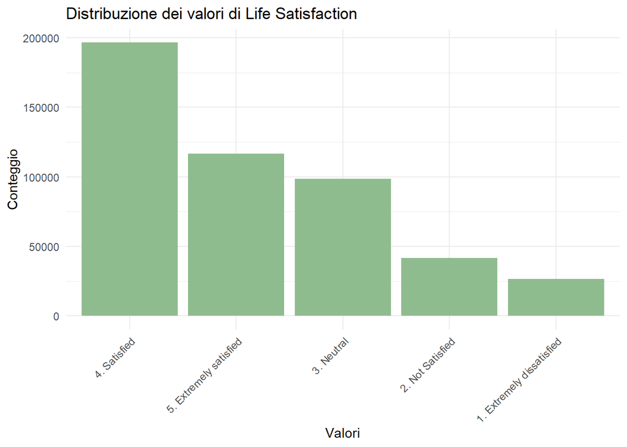

```r
library(ggplot2)

# Calculate the count of each category
count_data <- table(dati$Life_Satisfaction)

# Create the bar plot
p <- ggplot(data.frame(Category = names(count_data), Count = as.numeric(count_data)), aes(x = reorder(Category, -Count), y = Count)) +
  geom_bar(stat = "identity", fill = "darkseagreen") +
  labs(
    x = "Valori",
    y = "Conteggio",
    title = "Distribuzione dei valori di Life Satisfaction"
  ) +
  theme_minimal() +
  theme(axis.text.x = element_text(angle = 45, hjust = 1))

# Print the bar plot
print(p)
```

Distribuzione della variabile *Family Main Priority Life*

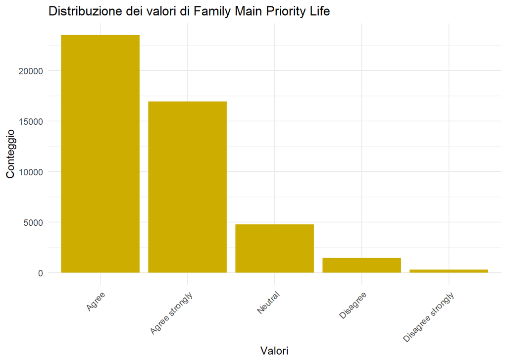

```r
library(ggplot2)

# Calculate the count of each category
count_data <- table(dati$Family_Main_Priority_Life)

# Create the bar plot
p <- ggplot(data.frame(Category = names(count_data), Count = as.numeric(count_data)), aes(x = reorder(Category, -Count), y = Count)) +
  geom_bar(stat = "identity", fill = "gold3") +
  labs(
    x = "Valori",
    y = "Conteggio",
    title = "Distribuzione dei valori di Family Main Priority Life"
  ) +
  theme_minimal() +
  theme(axis.text.x = element_text(angle = 45, hjust = 1))

# Print the bar plot
print(p)
```

Distribuzione delle variabili *Family Time*: Enjoyable e Stressful

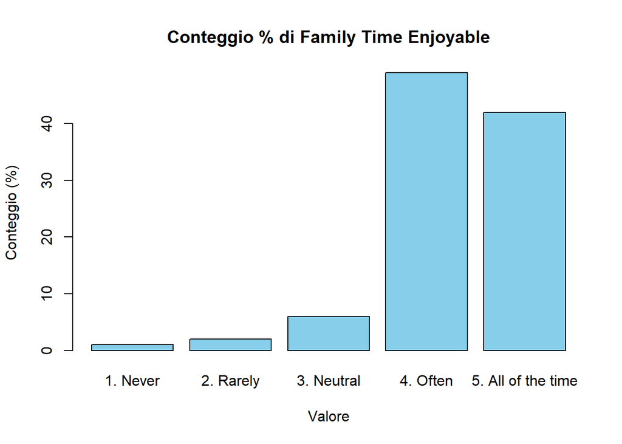

```r
# Count the occurrences of each value
freq_table_prop <- round(prop.table(table(dati$Family_Time_Enjoyable)), 2) * 100

# Create the bar plot
barplot(freq_table_prop, main = "Conteggio % di Family Time Enjoyable",
        xlab = "Valore", ylab = "Conteggio (%)", col = "skyblue")
```

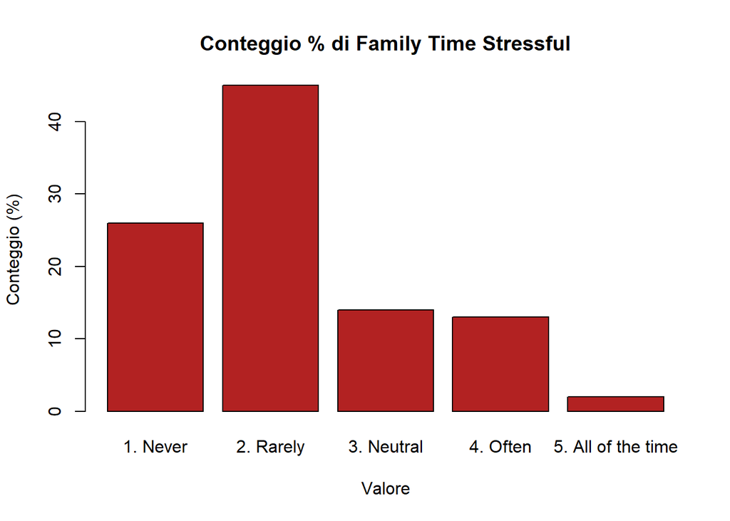

```r
# Count the occurrences of each value
freq_table_prop <- round(prop.table(table(dati$Family_Time_Stressful)), 2) * 100

# Create the bar plot
barplot(freq_table_prop, main = "Conteggio % di Family Time Stressful",
        xlab = "Valore", ylab = "Conteggio (%)", col = "firebrick")
```

Distribuzione delle variabili *Family Time*: Enjoyable e Stressful, per Country

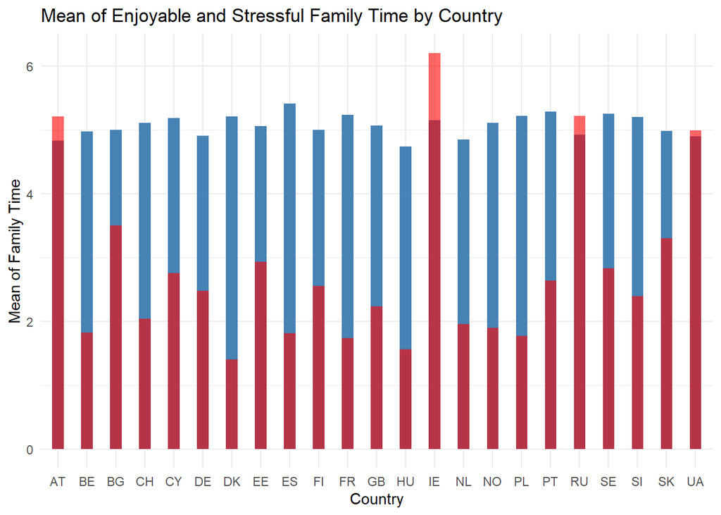

```r
library(data.table)

df <- dati_raw


# Filter out rows with null or empty values in Family_Time_Enjoyable and Family_Time_Stressful
df_filtered <- df[complete.cases(df$Family_Time_Enjoyable, df$Family_Time_Stressful) &
                    df$Family_Time_Enjoyable != "" & df$Family_Time_Stressful != "", ]

# Define values to be excluded
exclude_values <- c(55, 77, 88, 99)

# Exclude rows with values in Family_Time_Enjoyable column
df_filtered <- df_filtered[!Family_Time_Enjoyable %in% exclude_values]

# Calculate the mean of Family_Time_Enjoyable and Family_Time_Stressful by Country
df_mean <- df_filtered[
  , .(Mean_Enjoyable = mean(Family_Time_Enjoyable), Mean_Stressful = mean(Family_Time_Stressful)),
  by = Country
]

# Create the interactive bar-in-bar chart
p <- ggplot(df_mean, aes(x = Country)) +
  geom_bar(aes(y = Mean_Enjoyable, fill = "Enjoyable"), stat = "identity", width = 0.4) +
  geom_bar(aes(y = Mean_Stressful, fill = "Stressful"), stat = "identity", width = 0.4, alpha = 0.6) +
  scale_fill_manual(values = c(Enjoyable = "steelblue", Stressful = "red"),
                    guide = guide_legend(title = "Family Time")) +
  labs(
    x = "Country",
    y = "Mean of Family Time",
    title = "Mean of Enjoyable and Stressful Family Time by Country"
  ) +
  theme_minimal() +
  theme(legend.position = "none")

# Print the chart
print(p)
```

Distribuzione Variabili Sociali

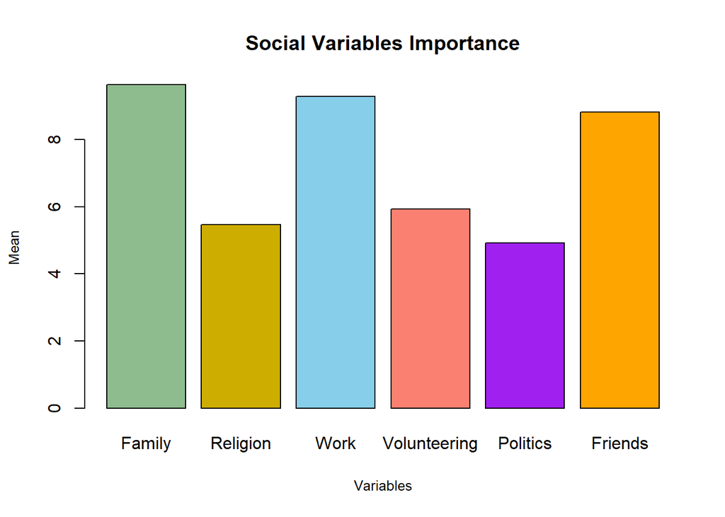

```r
# Define new variable names
variable_names <- c("Family", "Religion", "Work", "Volunteering", "Politics", "Friends")

# Calculate variable means
variable_mean <- colMeans(dati_raw[, c("Family_Importance", "Religion_Importance", "Work_Importance", "Volunteering_Importance", "Politics_Importance", "Friends_Importance")], na.rm = TRUE)

# Barplot of variable means with modified names
barplot(variable_mean,
        main = "Social Variables Importance",
        xlab = "Variables",
        ylab = "Mean",
        col = c("darkseagreen", "gold3", "skyblue", "salmon", "purple", "orange"),
        cex.lab = 0.8,
        beside = TRUE,
        names.arg = variable_names)  # Set the modified variable names
```

## Test delle Ipotesi

### 1. Definizione della variabile **dipendente** e **indipendente**

Variabile dipendente: Happiness, Life Satisfaction  
Variabili indipendenti: gender, country, Family_Main_Priority

**Obiettivo**: Vogliamo analizzare se esiste una dipendenza tra il benessere di una persona (inteso come Happiness e Life Satisfaction) rispetto all’importanza che dà alla famiglia.

### 2. Analisi statistiche

Tabella di Contingenza tra *Family Main Priority in Life* e *Happiness*

```r
# Tabella di contingenza
# con le percentuali, round a due decimali
FamilyMainPriority_Happiness <- round( prop.table(
                        table(dati$Family_Main_Priority_Life, dati$Happiness, useNA = "no")),
                      digits=4)*100

FamilyMainPriority_Happiness
```

```
##
##                     1. Very Unhappy 2. Unhappy 3. Neutral 4. Happy
##   Agree                        1.20       2.69      10.11    23.30
##   Agree strongly               1.47       2.36       7.60    14.09
##   Disagree                     0.07       0.16       0.52     1.50
##   Disagree strongly            0.03       0.04       0.11     0.29
##   Neutral                      0.28       0.57       2.17     5.11
##
##                     5. Very Happy
##   Agree                     12.76
##   Agree strongly            10.50
##   Disagree                   0.86
##   Disagree strongly          0.17
##   Neutral                    2.03
```

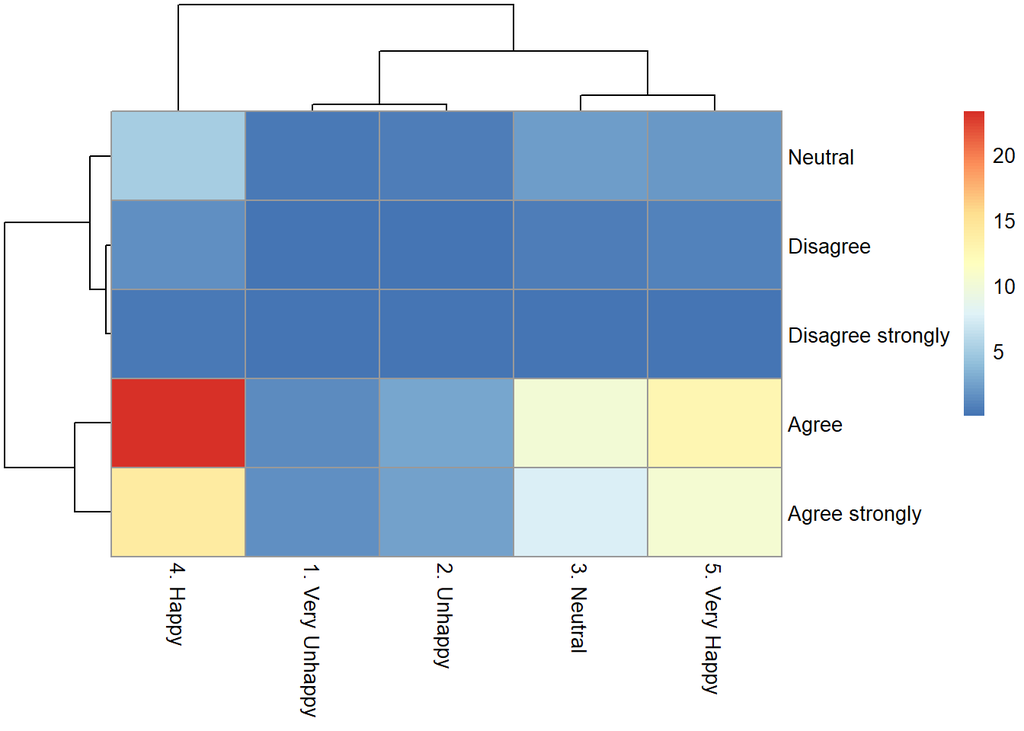

```r
#paste("Numero di Osservazioni: ", nrow(dati))

# Grafico di Correlazione
library("pheatmap")
pheatmap(as.matrix(FamilyMainPriority_Happiness))
```

Correlazione tra *Family Main Priority in Life* e *Happiness*, analisi per Country, soglia variabile (ex.30%)

```r
# Supponiamo che il tuo dataset si chiami "data" e la colonna del paese si chiami "Country"

# Ottenere la lista dei paesi unici
paesi <- unique(dati$Country)

# Definire una funzione per trovare i massimi e controllare il 50%
trova_massimi <- function(paese) {
  # Selezionare i dati solo per il paese corrente
  dati_paese <- subset(dati, Country == paese)

  # Creare la tabella di contingenza per il paese corrente
  tabella <- table(dati_paese$Happiness, dati_paese$Family_Main_Priority_Life)

  # Controllare se la tabella di contingenza è vuota
  if (length(tabella) == 0) {
    return(NULL)  # Restituire NULL se la tabella è vuota
  }
  #Trovare il massimo valore nella tabella di contingenza
  #massimo <- ifelse(length(tabella) > 0, max(tabella), 0)

  # Trovare il massimo valore nella tabella di contingenza
  massimo <- max(tabella, na.rm =TRUE)

  # Calcolare la proporzione del massimo rispetto al totale
  proporzione <- massimo / sum(tabella)

  # Controllare se la proporzione supera la soglia
  if (proporzione > 0.30) {
    return(paese)  # Restituire il nome del paese se il massimo supera il 50%
  } else {
    return(NULL)  # Restituire NULL altrimenti
  }
}

# lapply per applicare la funzione a ciascun paese
paesi_contingency_soglia <- lapply(paesi, trova_massimi)

# Filtrare eventuali valori NULL dalla lista risultante
paesi_contingency_soglia <- paesi_contingency_soglia[!sapply(paesi_contingency_soglia, is.null)]

# Visualizzare i paesi con correlazione superiore alla soglia
print(paesi_contingency_soglia)
```

```
## [[1]]
## [1] "Switzerland"
##
## [[2]]
## [1] "Netherlands"
##
## [[3]]
## [1] "Sweden"
##
## [[4]]
## [1] "Iceland"
```

Test chi2

```r
chi2 <- chisq.test(FamilyMainPriority_Happiness)
print(chi2)
```

```
##
##  Pearson's Chi-squared test
##
## data:  FamilyMainPriority_Happiness
## X-squared = 0.9503, df = 16, p-value = 1
```

```r
#l’associazione tra le due variabili nella tabella di contingenza può essere attribuita al caso;
# un valore di p-value superiore a 0.05 indica che la relazione non è statisticamente significativa e dunque non si può respingere l’ipotesi nulla, per cui si conclude che le due variabili sono statisticamente indipendenti
```

V di Cramer

```r
#install.packages("rcompanion")
#lanciamo
library(rcompanion)

#Calcoliamo la V di Cramer
cramerV(FamilyMainPriority_Happiness)
```

```
## Cramer V
##  0.04874
```

```r
# associazione debole
```

Tabella di Contingenza tra *Family Main Priority in Life* e *Life Satisfaction*

```r
# Tabella di contingenza
# con le percentuali, round a due decimali
Family_LifeSatisfaction <- round( prop.table(
                        table(dati$Family_Main_Priority_Life, dati$Life_Satisfaction, useNA = "no")),
                      digits=4)*100

Family_LifeSatisfaction
```

```
##
##                     1. Extremely dissatisfied 2. Not Satisfied 3. Neutral
##   Agree                                  2.41             4.07      10.52
##   Agree strongly                         2.57             3.39       7.89
##   Disagree                               0.12             0.25       0.59
##   Disagree strongly                      0.05             0.06       0.13
##   Neutral                                0.47             0.84       2.26
##
##                     4. Satisfied 5. Extremely satisfied
##   Agree                    21.06                  11.98
##   Agree strongly           12.83                   9.35
##   Disagree                  1.33                   0.84
##   Disagree strongly         0.22                   0.19
##   Neutral                   4.48                   2.11
```

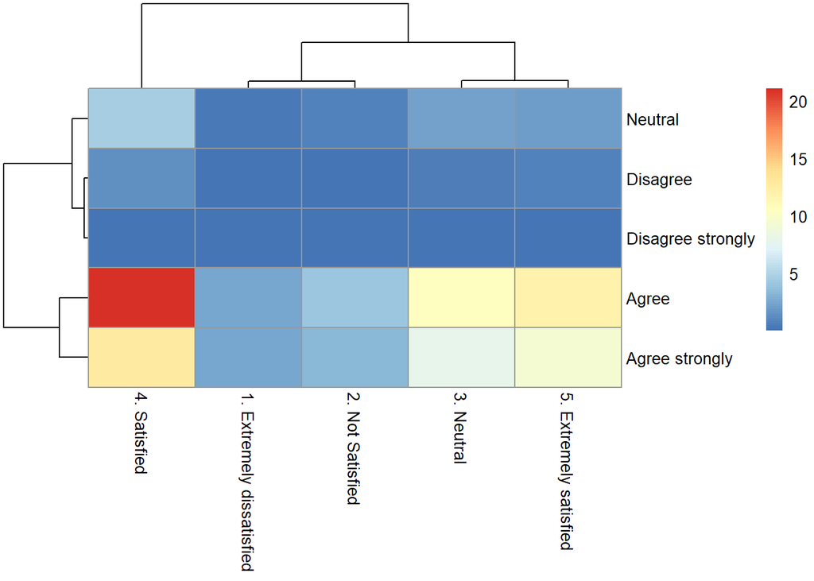

```r
# Grafico di Correlazione
library("pheatmap")
pheatmap(as.matrix(Family_LifeSatisfaction))
```

Test chi2

```r
chi2 <- chisq.test(Family_LifeSatisfaction)
print(chi2)
```

```
##
##  Pearson's Chi-squared test
##
## data:  Family_LifeSatisfaction
## X-squared = 0.69912, df = 16, p-value = 1
```

```r
#l’associazione tra le due variabili nella tabella di contingenza può essere attribuita al caso;
# un valore di p-value superiore a 0.05 indica che la relazione non è statisticamente significativa e dunque non si può respingere l’ipotesi nulla, per cui si conclude che le due variabili sono statisticamente indipendenti
```

V di Cramer

```r
#install.packages("rcompanion")
#lanciamo
library(rcompanion)

#Calcoliamo la V di Cramer
cramerV(Family_LifeSatisfaction)
```

```
## Cramer V
##   0.0418
```

```r
# associazione debole
```

## Conclusioni

1. Quali sono i principali risultati dell’analisi?
2. Di quali limiti si caratterizza l’analisi? periodo temporale e missing values!
3. Quali ulteriori analisi potrebbero essere svolte?

### 1. Quali sono i principali risultati dell’analisi?

- La relazione tra l’importanza della famiglia e la felicità non ha mostrato significatività statistica, con un p-value = 1 (>> 0.05) e una V di Cramer molto bassa di 0.048.
- La relazione tra l’importanza della famiglia e la soddifazione nella vita è anch’essa poco rilevante con un p-value = 1 e una V di Cramer di 0.0418.

### 2. Di quali limiti si caratterizza l’analisi?

Purtroppo, il nostro dataset era limitato a un solo anno, il 2018. Pertanto, non siamo stati in grado di analizzare i cambiamenti nel tempo, come ad esempio il miglioramento o il peggioramento dell’importanza della famiglia nel corso degli anni. Inoltre, molte delle variabili selezionate presentavano valori mancanti.

### 3. Quali ulteriori analisi potrebbero essere svolte?

Ulteriori analisi che avremmo potuto condurre sui dati includono l’importanza dei figli e il loro impatto sulla felicità individuale, nonché l’esplorazione della relazione tra il tempo trascorso al lavoro e la felicità personale e della famiglia. In aggiunta a ciò un’interessante analisi potrebbe essere fatta sui dati post-pandemia per rivelare eventuali cambiamenti.